# HW2

Bryan Yang

4/26/2022

## Task 1

Read in the ities.csv datafile as a dataframe object, **df**.

```r
df <- read.csv('ities.csv', stringsAsFactors = F, header = T)
```

*No descriptive answer is needed here.*

## Task 2

**(2 points) Display the count of rows and columns in the dataframe using an appropriate R function. Below the output, identify the count of rows and the count of columns.**

```r
# Count of rows and the count of columns: Dimension
dim(df)
```

```
## [1] 438151     13
```

```r
# Count of rows
nrow(df)
```

```
## [1] 438151
```

```r
# Count of columns
ncol(df)
```

```
## [1] 13
```

## Task 3

**(3 points) Use the appropriate R function to display the structure (i.e., number of rows, columns, column names, column data type, some values from each column) of the dataframe, df. Below the output, briefly summarize two main points about the dataframe structure.**

```r
# Structure of Dataframe, df
str(df)
```

```
## 'data.frame':    438151 obs. of  13 variables:
##  $ Date             : chr  "7/18/2016" "7/18/2016" "7/18/2016" "7/18/2016" ...
##  $ OperationType    : chr  "SALE" "SALE" "SALE" "SALE" ...
##  $ CashierName      : chr  "Wallace Kuiper" "Wallace Kuiper" "Wallace Kuiper" "Wallace Kuiper" ...
##  $ LineItem         : chr  "Salmon and Wheat Bran Salad" "Fountain Drink" "Beef and Squash Kabob" "Salmon and Wheat Bran Salad" ...
##  $ Department       : chr  "Entrees" "Beverage" "Kabobs" "Salad" ...
##  $ Category         : chr  "Salmon and Wheat Bran Salad" "Fountain" "Beef" "general" ...
##  $ RegisterName     : chr  "RT149" "RT149" "RT149" "RT149" ...
##  $ StoreNumber      : chr  "AZ23501305" "AZ23501289" "AZ23501367" "AZ23501633" ...
##  $ TransactionNumber: chr  "002XIIC146121" "002XIIC146121" "00PG9FL135736" "00Z3B4R37335" ...
##  $ CustomerCode     : chr  "CWM11331L8O" "CWM11331L8O" "CWM11331L8O" "CWM11331L8O" ...
##  $ Price            : num  66.22 2.88 12.02 18.43 18.43 ...
##  $ Quantity         : int  1 1 2 1 1 1 1 1 1 1 ...
##  $ TotalDue         : num  66.22 2.88 24.04 18.43 18.43 ...
```

### Two main points about the dataframe structure:

- Columns are of different data types (chr, int, and num).
- The row of the dataframe shows line item being sold with column displaying different information about the transaction.

## Task 4

**(6 points) True or False: Every transaction is summarized in one row of the dataframe. Display at least one calculation in the code chunk below. Below the calculation(s), clearly indicate whether the statement is true or false and explain how the output of your calculation(s) supports your conclusion.**

```r
df[1,]
```

```
##        Date OperationType    CashierName                    LineItem Department
## 1 7/18/2016          SALE Wallace Kuiper Salmon and Wheat Bran Salad    Entrees
##                      Category RegisterName StoreNumber TransactionNumber
## 1 Salmon and Wheat Bran Salad        RT149  AZ23501305     002XIIC146121
##   CustomerCode Price Quantity TotalDue
## 1  CWM11331L8O 66.22        1    66.22
```

```r
df[10,]
```

```
##         Date OperationType    CashierName       LineItem Department Category
## 10 7/18/2016          SALE Wallace Kuiper Fountain Drink   Beverage Fountain
##    RegisterName StoreNumber TransactionNumber CustomerCode Price Quantity
## 10        RT149  AZ23501289     00X067D173851  CWM11331L8O  2.88        1
##    TotalDue
## 10     2.88
```

```r
df[100,]
```

```
##          Date OperationType    CashierName                        LineItem
## 100 7/18/2016          SALE Wallace Kuiper Aubergine and Chickpea Vindaloo
##     Department                        Category RegisterName StoreNumber
## 100    Entrees Aubergine and Chickpea Vindaloo        RT149  AZ23501473
##     TransactionNumber CustomerCode Price Quantity TotalDue
## 100      0063VEG61756  CWM11331L8O  4.83        1     4.83
```

```r
df[1000,]
```

```
##           Date OperationType CashierName   LineItem Department   Category
## 1000 7/15/2016          SALE  Mary Jones Lamb Chops    Entrees Lamb Chops
##      RegisterName StoreNumber TransactionNumber CustomerCode Price Quantity
## 1000        RT149  AZ23501251     00VLTVE188451   C5Q96950NZ  5.92        1
##      TotalDue
## 1000     5.92
```

```r
df[10000,]
```

```
##            Date OperationType     CashierName              LineItem Department
## 10000 6/18/2016          SALE Stephanie Raven Beef and Squash Kabob     Kabobs
##       Category RegisterName StoreNumber TransactionNumber CustomerCode Price
## 10000     Beef        RT149  AZ23501367      00GJ04F66321  CWM11331L8O 12.02
##       Quantity TotalDue
## 10000        1    12.02
```

```r
df[100000,]
```

```
##             Date OperationType   CashierName       LineItem Department Category
## 100000 10/8/2015          SALE Rachael Price Fountain Drink   Beverage Fountain
##        RegisterName StoreNumber TransactionNumber CustomerCode Price Quantity
## 100000        RT149  AZ23501289     002KW9U149662  CWM11331L8O  2.88        2
##        TotalDue
## 100000     5.76
```

```r
df[400000,]
```

```
##             Date OperationType       CashierName              LineItem
## 400000 3/11/2017          SALE Nicholas Villines Pork and Pepper Kabob
##        Department Category RegisterName StoreNumber TransactionNumber
## 400000     Kabobs     Pork        RT149  AZ23501343      009B88B54482
##        CustomerCode Price Quantity TotalDue
## 400000  CWM11331L8O 12.66        1    12.66
```

## Task 5

**(3 points) Display the summaries of the Price, Quantity and TotalDue columns. Below the output, provide a brief interpretation of the output for each column.**

```r
df[1:5,c('Price','Quantity','TotalDue')]
```

```
##   Price Quantity TotalDue
## 1 66.22        1    66.22
## 2  2.88        1     2.88
## 3 12.02        2    24.04
## 4 18.43        1    18.43
## 5 18.43        1    18.43
```

### Outcome of display:

- Price column shows price of the line item sold.
- Quantity column shows number of units of the line item sold.
- TotalDue column shows product of price per unit and quantity sold.

## Task 6

**(6 points) Display the boxplots of the log values for the Price, Quantity and TotalDue columns. Below the output, provide a brief description of three insights that you see in the boxplots. As part of your description, indicate how the output from task 5 relates to the boxplots in this task.**

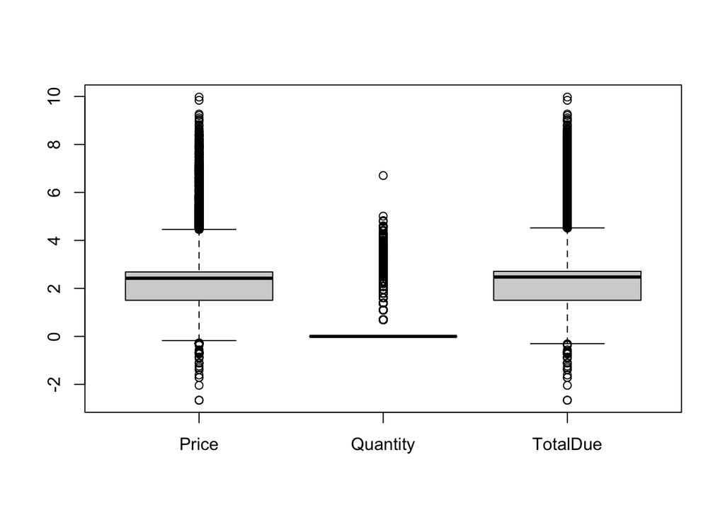

```r
boxplot(log(df[, c('Price', 'Quantity', 'TotalDue')]))
```